# Sex Differences in Functional Connectivity

Audrey Luo

```r
red_teal_white_base <- rev(c( "#A51122FF","#E14C21FF", "#F8A86BFF", "#FFFFFFFF","#ACDFD3FF", "#0B8CACFF","#324DA0FF"))
red_teal_white <- colorRampPalette(red_teal_white_base)
```

```r
# load S-A axis
schaefer200x17_SAaxis <- read.csv(file.path(root, "SAaxis", "schaefer200x17_SAaxis.csv"))
schaefer200x17_SAaxis <- schaefer200x17_SAaxis %>% rename(region=label)

# load parcel labels
schaefer200x17.labels <- read.csv(file.path(root, "atlases", "parcellations", "schaefer200x17_regionlist_final.csv"))
schaefer200x17.labels <- schaefer200x17.labels$label

# load network-pair labels
schaefer200x17.networkpair.labels <- read.csv(file.path(root, "atlases", "parcellations", "schaefer200x17_netpair_labels_noduplicates.csv"))
schaefer200x17.networkpair.labels <- schaefer200x17.networkpair.labels[,1]

# load permuted schaefer200
perm.id.full_schaefer200x17 <- readRDS(file.path(root, "software", "rotate_parcellation", "schaefer200x17.coords_sphericalrotations_N10k_seed10.rds"))
```

# 1. Males exhibit greater functional connectivity strength across the cortex

```r
sex.main.PNC.FC_strength <- read.csv(sprintf("%1$s/%2$s/GAM/%3$s/%2$s_GAM_sex_maineffects_schaefer200x17.csv", output_root, "PNC", "FC_strength"))
sex.main.PNC.FC_strength$region <- paste0("17", sex.main.PNC.FC_strength$region)
sex.main.PNC.FC_strength <- sig.effects(sex.main.PNC.FC_strength, "FC_strength", "sex", "PNC")
```

```
## [1] "PNC: 154 regions (77 percent) show a significant association between FC_strength and sex"
```

```r
resi.PNC.FC_strength <- read.csv(file.path(root, "covariate_analyses", "sex_diff", "output", "PNC", "resi", "FC_strength", "PNC_resiPEse_Th1_sex_maineffects_schaefer200x17.csv"))
resi.PNC.FC_strength$region <- paste0("17", resi.PNC.FC_strength$region )
resi.PNC.FC_strength <- resi.PNC.FC_strength %>% rename(RESI = RESI_Xinyu) %>% select(region, RESI)
sex.main.PNC.FC_strength <- merge(sex.main.PNC.FC_strength, resi.PNC.FC_strength)

sex.main.HCPD.FC_strength <- read.csv(sprintf("%1$s/%2$s/GAM/%3$s/%2$s_GAM_sex_maineffects_schaefer200x17.csv", output_root, "HCPD", "FC_strength"))
sex.main.HCPD.FC_strength <- sig.effects(sex.main.HCPD.FC_strength, "FC_strength", "sex", "HCPD")
```

```
## [1] "HCPD: 56 regions (28 percent) show a significant association between FC_strength and sex"
```

```r
sex.main.HCPD.FC_strength$region <- paste0("17", sex.main.HCPD.FC_strength$region)
resi.HCPD.FC_strength <- read.csv(file.path(root, "covariate_analyses", "sex_diff", "output", "HCPD", "resi", "FC_strength", "HCPD_resiPEse_Th1_sex_maineffects_schaefer200x17.csv"))
resi.HCPD.FC_strength$region <- paste0("17", resi.HCPD.FC_strength$region )
resi.HCPD.FC_strength <- resi.HCPD.FC_strength %>% rename(RESI = RESI_Xinyu) %>% select(region, RESI)
sex.main.HCPD.FC_strength <- merge(sex.main.HCPD.FC_strength, resi.HCPD.FC_strength)

sex.main.NKI.FC_strength <- read.csv(sprintf("%1$s/%2$s/GAM/%3$s/%2$s_GAM_sex_maineffects_schaefer200x17.csv", output_root, "NKI", "FC_strength"))
sex.main.NKI.FC_strength <- sig.effects(sex.main.NKI.FC_strength, "FC_strength", "sex", "NKI")
```

```
## [1] "NKI: 33 regions (16.5 percent) show a significant association between FC_strength and sex"
```

```r
sex.main.NKI.FC_strength$region <- paste0("17", sex.main.NKI.FC_strength$region)
resi.NKI.FC_strength <- read.csv(file.path(root, "covariate_analyses", "sex_diff", "output", "NKI", "resi", "FC_strength", "NKI_resiPEse_Th1_sex_maineffects_schaefer200x17.csv"))
resi.NKI.FC_strength$region <- paste0("17", resi.NKI.FC_strength$region )
resi.NKI.FC_strength <- resi.NKI.FC_strength %>% rename(RESI = RESI_Xinyu) %>% select(region, RESI)
sex.main.NKI.FC_strength <- merge(sex.main.NKI.FC_strength, resi.NKI.FC_strength)

sex.main.HBN.FC_strength <- read.csv(sprintf("%1$s/%2$s/GAM/%3$s/%2$s_GAM_sex_maineffects_schaefer200x17.csv", output_root, "HBN", "FC_strength"))
sex.main.HBN.FC_strength <- sig.effects(sex.main.HBN.FC_strength, "FC_strength", "sex", "HBN")
```

```
## [1] "HBN: 63 regions (31.5 percent) show a significant association between FC_strength and sex"
```

```r
sex.main.HBN.FC_strength$region <- paste0("17", sex.main.HBN.FC_strength$region)
resi.HBN.FC_strength <- read.csv(file.path(root, "covariate_analyses", "sex_diff", "output", "HBN", "resi", "FC_strength", "HBN_resiPEse_Th1_sex_maineffects_schaefer200x17.csv"))
resi.HBN.FC_strength$region <- paste0("17", resi.HBN.FC_strength$region )
resi.HBN.FC_strength <- resi.HBN.FC_strength %>% rename(RESI = RESI_Xinyu) %>% select(region, RESI)
sex.main.HBN.FC_strength <- merge(sex.main.HBN.FC_strength, resi.HBN.FC_strength)

sex.main.all_datasets.FC_strength <- read.csv(sprintf("%1$s/%2$s/GAM/%3$s/%2$s_GAM_sex_maineffects_schaefer200x17.csv", output_root, "all_datasets", "FC_strength"))
sex.main.all_datasets.FC_strength <- sig.effects(sex.main.all_datasets.FC_strength, "FC_strength", "sex", "all_datasets")
```

```
## [1] "all_datasets: 178 regions (89 percent) show a significant association between FC_strength and sex"
```

```r
sex.main.all_datasets.FC_strength$region <- paste0("17", sex.main.all_datasets.FC_strength$region)
resi.all_datasets.FC_strength <- read.csv(file.path(root, "covariate_analyses", "sex_diff", "output", "all_datasets", "resi", "FC_strength", "all_datasets_resiPEse_Th1_sex_maineffects_schaefer200x17.csv"))
resi.all_datasets.FC_strength$region <- paste0("17", resi.all_datasets.FC_strength$region )
resi.all_datasets.FC_strength <- resi.all_datasets.FC_strength %>% rename(RESI = RESI_Xinyu) %>% select(region, RESI)
sex.main.all_datasets.FC_strength <- merge(sex.main.all_datasets.FC_strength, resi.all_datasets.FC_strength)
```

```r
sex.main.PNC.FC_strength_lh_resi <- plot_cortex(sex.main.PNC.FC_strength, hemi = "left", measure = "RESI", ylim1 = -0.26, ylim2 = 0.1, atlas = "schaefer17_200")
sex.main.PNC.FC_strength_rh_resi <- plot_cortex(sex.main.PNC.FC_strength, hemi = "right", measure = "RESI", ylim1 = -0.26, ylim2 = 0.1, atlas = "schaefer17_200")

sex.main.HCPD.FC_strength_lh_resi <- plot_cortex(sex.main.HCPD.FC_strength, hemi = "left", measure = "RESI", ylim1 = -0.26, ylim2 = 0.1, atlas = "schaefer17_200")
sex.main.HCPD.FC_strength_rh_resi <- plot_cortex(sex.main.HCPD.FC_strength, hemi = "right", measure = "RESI", ylim1 = -0.26, ylim2 = 0.1, atlas = "schaefer17_200")

sex.main.NKI.FC_strength_lh_resi <- plot_cortex(sex.main.NKI.FC_strength, hemi = "left", measure = "RESI", ylim1 = -0.26, ylim2 = 0.1, atlas = "schaefer17_200")
sex.main.NKI.FC_strength_rh_resi <- plot_cortex(sex.main.NKI.FC_strength, hemi = "right", measure = "RESI", ylim1 = -0.26, ylim2 = 0.1, atlas = "schaefer17_200")

sex.main.HBN.FC_strength_lh_resi <- plot_cortex(sex.main.HBN.FC_strength, hemi = "left", measure = "RESI", ylim1 = -0.26, ylim2 = 0.1, atlas = "schaefer17_200")
sex.main.HBN.FC_strength_rh_resi <- plot_cortex(sex.main.HBN.FC_strength, hemi = "right", measure = "RESI", ylim1 = -0.26, ylim2 = 0.1, atlas = "schaefer17_200")

sex.main.all_datasets.FC_strength_lh_resi <- plot_cortex(sex.main.all_datasets.FC_strength, hemi = "left", measure = "RESI", ylim1 = -0.26, ylim2 = 0.1, atlas = "schaefer17_200", horizontal_layout = TRUE)
sex.main.all_datasets.FC_strength_rh_resi <- plot_cortex(sex.main.all_datasets.FC_strength, hemi = "right", measure = "RESI", ylim1 = -0.26, ylim2 = 0.1, atlas = "schaefer17_200", horizontal_layout = TRUE)


# legend
ylim1 = -0.26
ylim2 = 0.1
p <- ggplot() +
  geom_brain(data = sex.main.HBN.FC_strength, atlas = schaefer17_200, mapping = aes(fill = RESI), show.legend = TRUE) +
  scale_fill_gradientn(colours = red_teal_white(256), values = scales::rescale(c(ylim1, 0, ylim2)), limits = c(ylim1, ylim2), oob = squish, na.value = "white") +
  theme_void() +
  theme(legend.title = element_blank(), legend.text = element_text(size = 12), legend.position = "bottom", legend.box = "horizontal",
        legend.key.height = unit(0.53, "cm"), legend.key.width = unit(1.07, "cm"), plot.margin = unit(c(0, 0.53, 0, -0.27), "cm"))

legend <- get_legend(p)
legend <- ggdraw() +
  draw_plot(legend, x = 0.23, y = 0, width = 0.54, height = 1) +
  draw_label("Male > Female", x = 0.098, y = 0.66, size = 12, hjust = 0) +
  draw_label("Female > Male", x = 0.9, y = 0.66, size = 12, hjust = 1)

# arrange plots
# PNC
FC_strength_PNC <- annotate_figure(
  plot_grid(sex.main.PNC.FC_strength_lh_resi, sex.main.PNC.FC_strength_rh_resi, ncol = 2),
  top = text_grob("PNC", size = 12, face = "bold")
)

# HCP-D
FC_strength_HCPD <- annotate_figure(
  plot_grid(sex.main.HCPD.FC_strength_lh_resi, sex.main.HCPD.FC_strength_rh_resi, ncol = 2),
  top = text_grob("HCP-D", size = 12, face = "bold")
)

# NKI
FC_strength_NKI <- annotate_figure(
  plot_grid(sex.main.NKI.FC_strength_lh_resi, sex.main.NKI.FC_strength_rh_resi, ncol = 2),
  top = text_grob("NKI", size = 12, face = "bold")
)

# HBN
FC_strength_HBN <- annotate_figure(
  plot_grid(sex.main.HBN.FC_strength_lh_resi, sex.main.HBN.FC_strength_rh_resi, ncol = 2),
  top = text_grob("HBN", size = 12, face = "bold")
)


# pooled dataset / all datasets
FC_strength_all <- annotate_figure(
  plot_grid(sex.main.all_datasets.FC_strength_lh_resi, sex.main.all_datasets.FC_strength_rh_resi, ncol = 2),
  top = text_grob("Pooled Dataset", size = 12, face = "bold")
)


FC_strength_plots_row1 <- plot_grid(FC_strength_PNC, FC_strength_HCPD, ncol = 2)
FC_strength_plots_row2 <- plot_grid(FC_strength_NKI, FC_strength_HBN, ncol = 2)
FC_strength_plots_row1and2 <- plot_grid(FC_strength_plots_row1, FC_strength_plots_row2, nrow = 2)
FC_strength_plots <- annotate_figure(
  plot_grid(NULL, FC_strength_plots_row1and2, FC_strength_all, legend, nrow = 4, rel_heights = c(0.05, 1.2, 0.35, 0.2)),
  top = text_grob("Functional Connectivity Strength", size = 12, face = "bold"),
  bottom = text_grob("Sex Effect (RESI)", size = 12, y = 1)
)
```

```r
# overlap plots
df_list_FC_strength <- list(
  PNC  = sex.main.PNC.FC_strength[, c("region", "cov.pvalue.fdr")] |> rename(p_PNC = cov.pvalue.fdr),
  HCPD = sex.main.HCPD.FC_strength[, c("region", "cov.pvalue.fdr")] |> rename(p_HCPD = cov.pvalue.fdr),
  NKI  = sex.main.NKI.FC_strength[,  c("region", "cov.pvalue.fdr")] |> rename(p_NKI = cov.pvalue.fdr),
  HBN  = sex.main.HBN.FC_strength[,  c("region", "cov.pvalue.fdr")] |> rename(p_HBN = cov.pvalue.fdr)
)

sex.main.overlap.FC_strength <- Reduce(function(x, y) full_join(x, y, by = "region"), df_list_FC_strength)
sex.main.overlap.FC_strength$signif_count <- rowSums(sex.main.overlap.FC_strength[, -1] < 0.05, na.rm = TRUE)
sex.main.overlap.FC_strength$signif_count_factor <- factor(
  sex.main.overlap.FC_strength$signif_count,
  levels = 0:4,
  labels = c("0", "1", "2", "3", "4")
)
sex.main.overlap.FC_strength <- sex.main.overlap.FC_strength %>% mutate(signif_greater_than_one = ifelse(signif_count > 1, "1", "0"))

count_colors <- c(
  "0" = "white",
  "1" = "white",
  "2" = "#fcdac0",
  "3" = "#e87b96",
  "4" = "#ad2a72"
)



FC_strength_overlap.lh <- plot_cortex_overlap(sex.main.overlap.FC_strength, hemi = "left", atlas = "schaefer17_200", horizontal_layout = T)
FC_strength_overlap.rh <- plot_cortex_overlap(sex.main.overlap.FC_strength, hemi = "right", atlas = "schaefer17_200", horizontal_layout = T)

FC_strength_overlap <- annotate_figure(
  plot_grid(FC_strength_overlap.lh, FC_strength_overlap.rh, ncol = 2),
  top = text_grob("Overlap of Significant Effects Across Datasets", size = 12, face = "bold")
)
# legend for overlap
count_colors_legend <- c(
  "0–1" = "white",
  "2"   = "#fcdac0",
  "3"   = "#e87b96",
  "4"   = "#ad2a72"
)

legend_df <- data.frame(
  overlap = factor(names(count_colors_legend),
                   levels = names(count_colors_legend))
)

legend_plot <- ggplot(data.frame(overlap = factor(names(count_colors_legend),
                                                  levels = names(count_colors_legend))),
                      aes(x = overlap, fill = overlap)) +
  geom_bar() +
  scale_fill_manual(
    values = count_colors_legend,
    guide = guide_legend(
      direction = "horizontal",
      label.position = "bottom",
      override.aes = list(
        colour = "black",   # outline boxes
        size = 1
      )
    )
  ) +
  theme_void() +
  theme(
    legend.title = element_blank(),
    legend.text  = element_text(size = 12),
    legend.key.size = unit(0.7, "cm"),
    legend.position = "bottom"
  )

# Extract the horizontal legend
overlap_legend <- get_legend(legend_plot)

overlap_FC_strength_plots <- annotate_figure(plot_grid(FC_strength_overlap, NULL, overlap_legend, nrow = 3, rel_heights = c(1, 0.25, 0.1)), bottom = text_grob("Number of Datasets", size = 12, y = -0.4))

FC_strength_plots_final <- plot_grid(
  FC_strength_plots, overlap_FC_strength_plots, NULL,
  nrow = 3, rel_heights = c(1, 0.277, 0.05),
  labels = c("A", "B", ""), label_size = 12,
  label_x = 0.015, label_y = c(0.99, 0.967, 1),
  hjust = 0, vjust = 1)
```

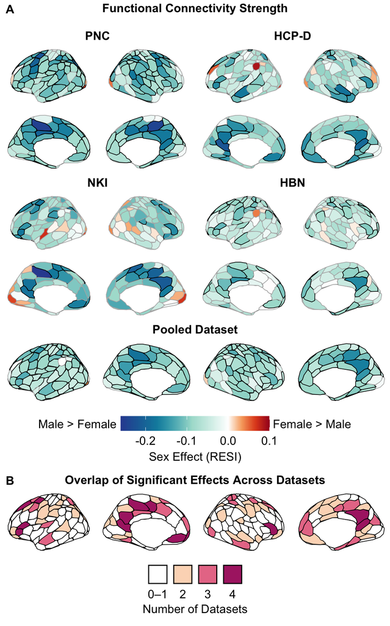

```r
FC_strength_plots_final
```

```r
#ggsave("/Users/audluo/Library/CloudStorage/Box-Box/Box_PhD_Land/PennLINC/sex_diff/sex_diff_manuscript/drafts/figures/fig1.tiff", plot = FC_strength_plots_final, width = 140, height = 224, units = "mm", dpi = 500,bg = "white")
```

### FC_strength count

```r
count_replication("FC_strength", "male")
```

```
## # A tibble: 3 × 5
##   measure     direction k         n   pct
##   <chr>       <chr>     <chr> <int> <dbl>
## 1 FC_strength male      2+       85  42.5
## 2 FC_strength male      3+       39  19.5
## 3 FC_strength male      4        14   7
```

### Regions showing significantly greater FC strength in females than males in one or more datasets.

| Region | No. of datasets |
| --- | --- |
| LH_VisCent_ExStr_2 | 1 |

# 2. Greater between-network connectivity contributes to greater functional connectivity strength in males

```r
sex.main.PNC.BNC <- read.csv(sprintf("%1$s/%2$s/GAM/%3$s/%2$s_GAM_sex_maineffects_schaefer200x17.csv", output_root, "PNC", "BNC"))
sex.main.PNC.BNC$region <- paste0("17", sex.main.PNC.BNC$region)
sex.main.PNC.BNC <- sig.effects(sex.main.PNC.BNC, "BNC", "sex", "PNC")
```

```
## [1] "PNC: 149 regions (74.5 percent) show a significant association between BNC and sex"
```

```r
resi.PNC.BNC <- read.csv(file.path(root, "covariate_analyses", "sex_diff", "output", "PNC", "resi", "BNC", "PNC_resiPEse_Th1_sex_maineffects_schaefer200x17.csv"))
resi.PNC.BNC$region <- paste0("17", resi.PNC.BNC$region )
resi.PNC.BNC <- resi.PNC.BNC %>% rename(RESI = RESI_Xinyu) %>% select(region, RESI)
sex.main.PNC.BNC <- merge(sex.main.PNC.BNC, resi.PNC.BNC)

sex.main.HCPD.BNC <- read.csv(sprintf("%1$s/%2$s/GAM/%3$s/%2$s_GAM_sex_maineffects_schaefer200x17.csv", output_root, "HCPD", "BNC"))
sex.main.HCPD.BNC <- sig.effects(sex.main.HCPD.BNC, "BNC", "sex", "HCPD")
```

```
## [1] "HCPD: 73 regions (36.5 percent) show a significant association between BNC and sex"
```

```r
sex.main.HCPD.BNC$region <- paste0("17", sex.main.HCPD.BNC$region)
resi.HCPD.BNC <- read.csv(file.path(root, "covariate_analyses", "sex_diff", "output", "HCPD", "resi", "BNC", "HCPD_resiPEse_Th1_sex_maineffects_schaefer200x17.csv"))
resi.HCPD.BNC$region <- paste0("17", resi.HCPD.BNC$region )
resi.HCPD.BNC <- resi.HCPD.BNC %>% rename(RESI = RESI_Xinyu) %>% select(region, RESI)
sex.main.HCPD.BNC <- merge(sex.main.HCPD.BNC, resi.HCPD.BNC)

sex.main.NKI.BNC <- read.csv(sprintf("%1$s/%2$s/GAM/%3$s/%2$s_GAM_sex_maineffects_schaefer200x17.csv", output_root, "NKI", "BNC"))
sex.main.NKI.BNC <- sig.effects(sex.main.NKI.BNC, "BNC", "sex", "NKI")
```

```
## [1] "NKI: 28 regions (14 percent) show a significant association between BNC and sex"
```

```r
sex.main.NKI.BNC$region <- paste0("17", sex.main.NKI.BNC$region)
resi.NKI.BNC <- read.csv(file.path(root, "covariate_analyses", "sex_diff", "output", "NKI", "resi", "BNC", "NKI_resiPEse_Th1_sex_maineffects_schaefer200x17.csv"))
resi.NKI.BNC$region <- paste0("17", resi.NKI.BNC$region )
resi.NKI.BNC <- resi.NKI.BNC %>% rename(RESI = RESI_Xinyu) %>% select(region, RESI)
sex.main.NKI.BNC <- merge(sex.main.NKI.BNC, resi.NKI.BNC)

sex.main.HBN.BNC <- read.csv(sprintf("%1$s/%2$s/GAM/%3$s/%2$s_GAM_sex_maineffects_schaefer200x17.csv", output_root, "HBN", "BNC"))
sex.main.HBN.BNC <- sig.effects(sex.main.HBN.BNC, "BNC", "sex", "HBN")
```

```
## [1] "HBN: 78 regions (39 percent) show a significant association between BNC and sex"
```

```r
sex.main.HBN.BNC$region <- paste0("17", sex.main.HBN.BNC$region)
resi.HBN.BNC <- read.csv(file.path(root, "covariate_analyses", "sex_diff", "output", "HBN", "resi", "BNC", "HBN_resiPEse_Th1_sex_maineffects_schaefer200x17.csv"))
resi.HBN.BNC$region <- paste0("17", resi.HBN.BNC$region )
resi.HBN.BNC <- resi.HBN.BNC %>% rename(RESI = RESI_Xinyu) %>% select(region, RESI)
sex.main.HBN.BNC <- merge(sex.main.HBN.BNC, resi.HBN.BNC)

sex.main.all_datasets.BNC <- read.csv(sprintf("%1$s/%2$s/GAM/%3$s/%2$s_GAM_sex_maineffects_schaefer200x17.csv", output_root, "all_datasets", "BNC"))
sex.main.all_datasets.BNC <- sig.effects(sex.main.all_datasets.BNC, "BNC", "sex", "all_datasets")
```

```
## [1] "all_datasets: 176 regions (88 percent) show a significant association between BNC and sex"
```

```r
sex.main.all_datasets.BNC$region <- paste0("17", sex.main.all_datasets.BNC$region)
resi.all_datasets.BNC <- read.csv(file.path(root, "covariate_analyses", "sex_diff", "output", "all_datasets", "resi", "BNC", "all_datasets_resiPEse_Th1_sex_maineffects_schaefer200x17.csv"))
resi.all_datasets.BNC$region <- paste0("17", resi.all_datasets.BNC$region )
resi.all_datasets.BNC <- resi.all_datasets.BNC %>% rename(RESI = RESI_Xinyu) %>% select(region, RESI)
sex.main.all_datasets.BNC <- merge(sex.main.all_datasets.BNC, resi.all_datasets.BNC)
```

```r
sex.main.PNC.BNC_lh_resi <- plot_cortex(sex.main.PNC.BNC, hemi = "left", measure = "RESI", ylim1 = -0.26, ylim2 = 0.1, atlas = "schaefer17_200")
sex.main.PNC.BNC_rh_resi <- plot_cortex(sex.main.PNC.BNC, hemi = "right", measure = "RESI", ylim1 = -0.26, ylim2 = 0.1, atlas = "schaefer17_200")

sex.main.HCPD.BNC_lh_resi <- plot_cortex(sex.main.HCPD.BNC, hemi = "left", measure = "RESI", ylim1 = -0.26, ylim2 = 0.1, atlas = "schaefer17_200")
sex.main.HCPD.BNC_rh_resi <- plot_cortex(sex.main.HCPD.BNC, hemi = "right", measure = "RESI", ylim1 = -0.26, ylim2 = 0.1, atlas = "schaefer17_200")

sex.main.NKI.BNC_lh_resi <- plot_cortex(sex.main.NKI.BNC, hemi = "left", measure = "RESI", ylim1 = -0.26, ylim2 = 0.1, atlas = "schaefer17_200")
sex.main.NKI.BNC_rh_resi <- plot_cortex(sex.main.NKI.BNC, hemi = "right", measure = "RESI", ylim1 = -0.26, ylim2 = 0.1, atlas = "schaefer17_200")

sex.main.HBN.BNC_lh_resi <- plot_cortex(sex.main.HBN.BNC, hemi = "left", measure = "RESI", ylim1 = -0.26, ylim2 = 0.1, atlas = "schaefer17_200")
sex.main.HBN.BNC_rh_resi <- plot_cortex(sex.main.HBN.BNC, hemi = "right", measure = "RESI", ylim1 = -0.26, ylim2 = 0.1, atlas = "schaefer17_200")

sex.main.all_datasets.BNC_lh_resi <- plot_cortex(sex.main.all_datasets.BNC, hemi = "left", measure = "RESI", ylim1 = -0.26, ylim2 = 0.1, atlas = "schaefer17_200", horizontal_layout = TRUE)
sex.main.all_datasets.BNC_rh_resi <- plot_cortex(sex.main.all_datasets.BNC, hemi = "right", measure = "RESI", ylim1 = -0.26, ylim2 = 0.1, atlas = "schaefer17_200", horizontal_layout = TRUE)


# legend
ylim1 = -0.26
ylim2 = 0.1
p <- ggplot() +
  geom_brain(data = sex.main.HBN.BNC, atlas = schaefer17_200, mapping = aes(fill = RESI), show.legend = TRUE) +
  scale_fill_gradientn(colours = red_teal_white(256), values = scales::rescale(c(ylim1, 0, ylim2)), limits = c(ylim1, ylim2), oob = squish, na.value = "white") +
  theme_void() +
  theme(legend.title = element_blank(), legend.text = element_text(size = 12), legend.position = "bottom", legend.box = "horizontal",
        legend.key.height = unit(0.53, "cm"), legend.key.width = unit(1.07, "cm"), plot.margin = unit(c(0, 0.53, 0, -0.27), "cm"))

legend <- get_legend(p)
legend <- ggdraw() +
  draw_plot(legend, x = 0.23, y = 0, width = 0.54, height = 1) +
  draw_label("Male > Female", x = 0.098, y = 0.66, size = 12, hjust = 0) +
  draw_label("Female > Male", x = 0.9, y = 0.66, size = 12, hjust = 1)

# arrange plots
# PNC
BNC_PNC <- annotate_figure(
  plot_grid(sex.main.PNC.BNC_lh_resi, sex.main.PNC.BNC_rh_resi, ncol = 2),
  top = text_grob("PNC", size = 12, face = "bold")
)

# HCP-D
BNC_HCPD <- annotate_figure(
  plot_grid(sex.main.HCPD.BNC_lh_resi, sex.main.HCPD.BNC_rh_resi, ncol = 2),
  top = text_grob("HCP-D", size = 12, face = "bold")
)

# NKI
BNC_NKI <- annotate_figure(
  plot_grid(sex.main.NKI.BNC_lh_resi, sex.main.NKI.BNC_rh_resi, ncol = 2),
  top = text_grob("NKI", size = 12, face = "bold")
)

# HBN
BNC_HBN <- annotate_figure(
  plot_grid(sex.main.HBN.BNC_lh_resi, sex.main.HBN.BNC_rh_resi, ncol = 2),
  top = text_grob("HBN", size = 12, face = "bold")
)


# pooled dataset / all datasets
BNC_all <- annotate_figure(
  plot_grid(sex.main.all_datasets.BNC_lh_resi, sex.main.all_datasets.BNC_rh_resi, ncol = 2),
  top = text_grob("Pooled Dataset", size = 12, face = "bold")
)

BNC_plots_row1 <- plot_grid(BNC_PNC, BNC_HCPD, ncol = 2)
BNC_plots_row2 <- plot_grid(BNC_NKI, BNC_HBN, ncol = 2)
BNC_plots_row1and2 <- plot_grid(BNC_plots_row1, BNC_plots_row2, nrow = 2)
BNC_plots <- annotate_figure(
  plot_grid(NULL, BNC_plots_row1and2, BNC_all, legend, nrow = 4, rel_heights = c(0.05, 1.2, 0.35, 0.2)),
  top = text_grob("Between-Network Connectivity", size = 12, face = "bold"),
  bottom = text_grob("Sex Effect (RESI)", size = 12, y = 1)
)
```

```r
# overlap plots
df_list_BNC <- list(
  PNC  = sex.main.PNC.BNC[, c("region", "cov.pvalue.fdr")] |> rename(p_PNC = cov.pvalue.fdr),
  HCPD = sex.main.HCPD.BNC[, c("region", "cov.pvalue.fdr")] |> rename(p_HCPD = cov.pvalue.fdr),
  NKI  = sex.main.NKI.BNC[,  c("region", "cov.pvalue.fdr")] |> rename(p_NKI = cov.pvalue.fdr),
  HBN  = sex.main.HBN.BNC[,  c("region", "cov.pvalue.fdr")] |> rename(p_HBN = cov.pvalue.fdr)
)

sex.main.overlap.BNC <- Reduce(function(x, y) full_join(x, y, by = "region"), df_list_BNC)
sex.main.overlap.BNC$signif_count <- rowSums(sex.main.overlap.BNC[, -1] < 0.05, na.rm = TRUE)
sex.main.overlap.BNC$signif_count_factor <- factor(
  sex.main.overlap.BNC$signif_count,
  levels = 0:4,
  labels = c("0", "1", "2", "3", "4")
)
sex.main.overlap.BNC <- sex.main.overlap.BNC %>% mutate(signif_greater_than_one = ifelse(signif_count > 1, "1", "0"))

count_colors <- c(
  "0" = "white",
  "1" = "white",
  "2" = "#fcdac0",
  "3" = "#e87b96",
  "4" = "#ad2a72"
)



BNC_overlap.lh <- plot_cortex_overlap(sex.main.overlap.BNC, hemi = "left", atlas = "schaefer17_200", horizontal_layout = T)
BNC_overlap.rh <- plot_cortex_overlap(sex.main.overlap.BNC, hemi = "right", atlas = "schaefer17_200", horizontal_layout = T)

BNC_overlap <- annotate_figure(
  plot_grid(BNC_overlap.lh, BNC_overlap.rh, ncol = 2),
  top = text_grob("Overlap of Significant Effects Across Datasets", size = 12, face = "bold")
)
# legend for overlap
count_colors_legend <- c(
  "0–1" = "white",
  "2"   = "#fcdac0",
  "3"   = "#e87b96",
  "4"   = "#ad2a72"
)

legend_df <- data.frame(
  overlap = factor(names(count_colors_legend),
                   levels = names(count_colors_legend))
)

legend_plot <- ggplot(data.frame(overlap = factor(names(count_colors_legend),
                                                  levels = names(count_colors_legend))),
                      aes(x = overlap, fill = overlap)) +
  geom_bar() +
  scale_fill_manual(
    values = count_colors_legend,
    guide = guide_legend(
      direction = "horizontal",
      label.position = "bottom",
      override.aes = list(
        colour = "black",   # outline boxes
        size = 1
      )
    )
  ) +
  theme_void() +
  theme(
    legend.title = element_blank(),
    legend.text  = element_text(size = 12),
    legend.key.size = unit(0.7, "cm"),
    legend.position = "bottom"
  )

# Extract the horizontal legend
overlap_legend <- get_legend(legend_plot)

overlap_BNC_plots <- annotate_figure(plot_grid(BNC_overlap, NULL, overlap_legend, nrow = 3, rel_heights = c(1, 0.25, 0.1)), bottom = text_grob("Number of Datasets", size = 12, y = -0.4))

BNC_plots_final <- plot_grid(
  BNC_plots, overlap_BNC_plots, NULL,
  nrow = 3, rel_heights = c(1, 0.277, 0.05),
  labels = c("A", "B", ""), label_size = 12,
  label_x = 0.015, label_y = c(0.99, 0.967, 1),
  hjust = 0, vjust = 1)
```

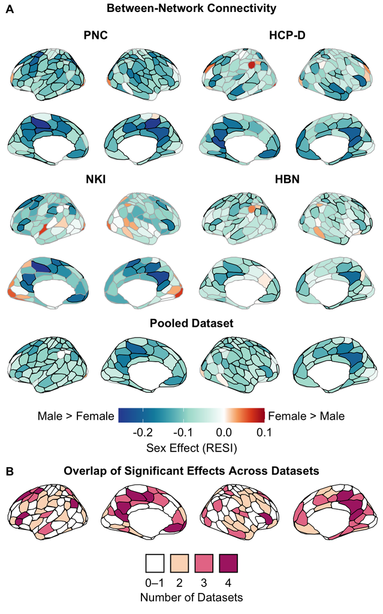

```r
BNC_plots_final
```

```r
#ggsave("/Users/audluo/Library/CloudStorage/Box-Box/Box_PhD_Land/PennLINC/sex_diff/sex_diff_manuscript/drafts/figures/fig2.tiff", plot = BNC_plots_final, width = 140, height = 224, units = "mm", dpi = 500,bg = "white")
```

### BNC count

```r
count_replication("BNC", "male")
```

```
## # A tibble: 3 × 5
##   measure direction k         n   pct
##   <chr>   <chr>     <chr> <int> <dbl>
## 1 BNC     male      2+       98    49
## 2 BNC     male      3+       52    26
## 3 BNC     male      4        16     8
```

### Regions showing significantly greater BNC in females than males in more than one dataset.

| Region | No. of datasets |
| --- | --- |
| None | — |

# 3. Females exhibit greater within-network connectivity in medial prefrontal, posterior cingulate, precuneus, and inferior parietal cortices

```r
sex.main.PNC.WNC <- read.csv(sprintf("%1$s/%2$s/GAM/%3$s/%2$s_GAM_sex_maineffects_schaefer200x17.csv", output_root, "PNC", "WNC"))
sex.main.PNC.WNC$region <- paste0("17", sex.main.PNC.WNC$region)
sex.main.PNC.WNC <- sig.effects(sex.main.PNC.WNC, "WNC", "sex", "PNC")
```

```
## [1] "PNC: 73 regions (36.5 percent) show a significant association between WNC and sex"
```

```r
resi.PNC.WNC <- read.csv(file.path(root, "covariate_analyses", "sex_diff", "output", "PNC", "resi", "WNC", "PNC_resiPEse_Th1_sex_maineffects_schaefer200x17.csv"))
resi.PNC.WNC$region <- paste0("17", resi.PNC.WNC$region )
resi.PNC.WNC <- resi.PNC.WNC %>% rename(RESI = RESI_Xinyu) %>% select(region, RESI)
sex.main.PNC.WNC <- merge(sex.main.PNC.WNC, resi.PNC.WNC)

sex.main.HCPD.WNC <- read.csv(sprintf("%1$s/%2$s/GAM/%3$s/%2$s_GAM_sex_maineffects_schaefer200x17.csv", output_root, "HCPD", "WNC"))
sex.main.HCPD.WNC <- sig.effects(sex.main.HCPD.WNC, "WNC", "sex", "HCPD")
```

```
## [1] "HCPD: 45 regions (22.5 percent) show a significant association between WNC and sex"
```

```r
sex.main.HCPD.WNC$region <- paste0("17", sex.main.HCPD.WNC$region)
resi.HCPD.WNC <- read.csv(file.path(root, "covariate_analyses", "sex_diff", "output", "HCPD", "resi", "WNC", "HCPD_resiPEse_Th1_sex_maineffects_schaefer200x17.csv"))
resi.HCPD.WNC$region <- paste0("17", resi.HCPD.WNC$region )
resi.HCPD.WNC <- resi.HCPD.WNC %>% rename(RESI = RESI_Xinyu) %>% select(region, RESI)
sex.main.HCPD.WNC <- merge(sex.main.HCPD.WNC, resi.HCPD.WNC)

sex.main.NKI.WNC <- read.csv(sprintf("%1$s/%2$s/GAM/%3$s/%2$s_GAM_sex_maineffects_schaefer200x17.csv", output_root, "NKI", "WNC"))
sex.main.NKI.WNC <- sig.effects(sex.main.NKI.WNC, "WNC", "sex", "NKI")
```

```
## [1] "NKI: 12 regions (6 percent) show a significant association between WNC and sex"
```

```r
sex.main.NKI.WNC$region <- paste0("17", sex.main.NKI.WNC$region)
resi.NKI.WNC <- read.csv(file.path(root, "covariate_analyses", "sex_diff", "output", "NKI", "resi", "WNC", "NKI_resiPEse_Th1_sex_maineffects_schaefer200x17.csv"))
resi.NKI.WNC$region <- paste0("17", resi.NKI.WNC$region )
resi.NKI.WNC <- resi.NKI.WNC %>% rename(RESI = RESI_Xinyu) %>% select(region, RESI)
sex.main.NKI.WNC <- merge(sex.main.NKI.WNC, resi.NKI.WNC)

sex.main.HBN.WNC <- read.csv(sprintf("%1$s/%2$s/GAM/%3$s/%2$s_GAM_sex_maineffects_schaefer200x17.csv", output_root, "HBN", "WNC"))
sex.main.HBN.WNC <- sig.effects(sex.main.HBN.WNC, "WNC", "sex", "HBN")
```

```
## [1] "HBN: 35 regions (17.5 percent) show a significant association between WNC and sex"
```

```r
sex.main.HBN.WNC$region <- paste0("17", sex.main.HBN.WNC$region)
resi.HBN.WNC <- read.csv(file.path(root, "covariate_analyses", "sex_diff", "output", "HBN", "resi", "WNC", "HBN_resiPEse_Th1_sex_maineffects_schaefer200x17.csv"))
resi.HBN.WNC$region <- paste0("17", resi.HBN.WNC$region )
resi.HBN.WNC <- resi.HBN.WNC %>% rename(RESI = RESI_Xinyu) %>% select(region, RESI)
sex.main.HBN.WNC <- merge(sex.main.HBN.WNC, resi.HBN.WNC)

sex.main.all_datasets.WNC <- read.csv(sprintf("%1$s/%2$s/GAM/%3$s/%2$s_GAM_sex_maineffects_schaefer200x17.csv", output_root, "all_datasets", "WNC"))
sex.main.all_datasets.WNC <- sig.effects(sex.main.all_datasets.WNC, "WNC", "sex", "all_datasets")
```

```
## [1] "all_datasets: 102 regions (51 percent) show a significant association between WNC and sex"
```

```r
sex.main.all_datasets.WNC$region <- paste0("17", sex.main.all_datasets.WNC$region)
resi.all_datasets.WNC <- read.csv(file.path(root, "covariate_analyses", "sex_diff", "output", "all_datasets", "resi", "WNC", "all_datasets_resiPEse_Th1_sex_maineffects_schaefer200x17.csv"))
resi.all_datasets.WNC$region <- paste0("17", resi.all_datasets.WNC$region )
resi.all_datasets.WNC <- resi.all_datasets.WNC %>% rename(RESI = RESI_Xinyu) %>% select(region, RESI)
sex.main.all_datasets.WNC <- merge(sex.main.all_datasets.WNC, resi.all_datasets.WNC)
```

```r
sex.main.PNC.WNC_lh_resi <- plot_cortex(sex.main.PNC.WNC, hemi = "left", measure = "RESI", ylim1 = -0.26, ylim2 = 0.3, atlas = "schaefer17_200")
sex.main.PNC.WNC_rh_resi <- plot_cortex(sex.main.PNC.WNC, hemi = "right", measure = "RESI", ylim1 = -0.26, ylim2 = 0.3, atlas = "schaefer17_200")

sex.main.HCPD.WNC_lh_resi <- plot_cortex(sex.main.HCPD.WNC, hemi = "left", measure = "RESI", ylim1 = -0.26, ylim2 = 0.3, atlas = "schaefer17_200")
sex.main.HCPD.WNC_rh_resi <- plot_cortex(sex.main.HCPD.WNC, hemi = "right", measure = "RESI", ylim1 = -0.26, ylim2 = 0.3, atlas = "schaefer17_200")

sex.main.NKI.WNC_lh_resi <- plot_cortex(sex.main.NKI.WNC, hemi = "left", measure = "RESI", ylim1 = -0.26, ylim2 = 0.3, atlas = "schaefer17_200")
sex.main.NKI.WNC_rh_resi <- plot_cortex(sex.main.NKI.WNC, hemi = "right", measure = "RESI", ylim1 = -0.26, ylim2 = 0.3, atlas = "schaefer17_200")

sex.main.HBN.WNC_lh_resi <- plot_cortex(sex.main.HBN.WNC, hemi = "left", measure = "RESI", ylim1 = -0.26, ylim2 = 0.3, atlas = "schaefer17_200")
sex.main.HBN.WNC_rh_resi <- plot_cortex(sex.main.HBN.WNC, hemi = "right", measure = "RESI", ylim1 = -0.26, ylim2 = 0.3, atlas = "schaefer17_200")

sex.main.all_datasets.WNC_lh_resi <- plot_cortex(sex.main.all_datasets.WNC, hemi = "left", measure = "RESI", ylim1 = -0.26, ylim2 = 0.3, atlas = "schaefer17_200", horizontal_layout = TRUE)
sex.main.all_datasets.WNC_rh_resi <- plot_cortex(sex.main.all_datasets.WNC, hemi = "right", measure = "RESI", ylim1 = -0.26, ylim2 = 0.3, atlas = "schaefer17_200", horizontal_layout = TRUE)


# legend
ylim1 = -0.26
ylim2 = 0.3
p <- ggplot() +
  geom_brain(data = sex.main.HBN.WNC, atlas = schaefer17_200, mapping = aes(fill = RESI), show.legend = TRUE) +
  scale_fill_gradientn(colours = red_teal_white(256), values = scales::rescale(c(ylim1, 0, ylim2)), limits = c(ylim1, ylim2), oob = squish, na.value = "white") +
  theme_void() +
  theme(legend.title = element_blank(), legend.text = element_text(size = 12), legend.position = "bottom", legend.box = "horizontal",
        legend.key.height = unit(0.53, "cm"), legend.key.width = unit(1.07, "cm"), plot.margin = unit(c(0, 0.53, 0, -0.27), "cm"))

legend <- get_legend(p)
legend <- ggdraw() +
  draw_plot(legend, x = 0.23, y = 0, width = 0.54, height = 1) +
  draw_label("Male > Female", x = 0.098, y = 0.66, size = 12, hjust = 0) +
  draw_label("Female > Male", x = 0.9, y = 0.66, size = 12, hjust = 1)

# arrange plots
# PNC
WNC_PNC <- annotate_figure(
  plot_grid(sex.main.PNC.WNC_lh_resi, sex.main.PNC.WNC_rh_resi, ncol = 2),
  top = text_grob("PNC", size = 12, face = "bold")
)

# HCP-D
WNC_HCPD <- annotate_figure(
  plot_grid(sex.main.HCPD.WNC_lh_resi, sex.main.HCPD.WNC_rh_resi, ncol = 2),
  top = text_grob("HCP-D", size = 12, face = "bold")
)

# NKI
WNC_NKI <- annotate_figure(
  plot_grid(sex.main.NKI.WNC_lh_resi, sex.main.NKI.WNC_rh_resi, ncol = 2),
  top = text_grob("NKI", size = 12, face = "bold")
)

# HBN
WNC_HBN <- annotate_figure(
  plot_grid(sex.main.HBN.WNC_lh_resi, sex.main.HBN.WNC_rh_resi, ncol = 2),
  top = text_grob("HBN", size = 12, face = "bold")
)


# pooled dataset / all datasets
WNC_all <- annotate_figure(
  plot_grid(sex.main.all_datasets.WNC_lh_resi, sex.main.all_datasets.WNC_rh_resi, ncol = 2),
  top = text_grob("Pooled Dataset", size = 12, face = "bold")
)


WNC_plots_row1 <- plot_grid(WNC_PNC, WNC_HCPD, ncol = 2)
WNC_plots_row2 <- plot_grid(WNC_NKI, WNC_HBN, ncol = 2)
WNC_plots_row1and2 <- plot_grid(WNC_plots_row1, WNC_plots_row2, nrow = 2)
WNC_plots <- annotate_figure(
  plot_grid(NULL, WNC_plots_row1and2, WNC_all, legend, nrow = 4, rel_heights = c(0.05, 1.2, 0.35, 0.2)),
  top = text_grob("Within-Network Connectivity", size = 12, face = "bold"),
  bottom = text_grob("Sex Effect (RESI)", size = 12, y = 1)
)
```

```r
# overlap plots
df_list_WNC <- list(
  PNC  = sex.main.PNC.WNC[, c("region", "cov.pvalue.fdr")] |> rename(p_PNC = cov.pvalue.fdr),
  HCPD = sex.main.HCPD.WNC[, c("region", "cov.pvalue.fdr")] |> rename(p_HCPD = cov.pvalue.fdr),
  NKI  = sex.main.NKI.WNC[,  c("region", "cov.pvalue.fdr")] |> rename(p_NKI = cov.pvalue.fdr),
  HBN  = sex.main.HBN.WNC[,  c("region", "cov.pvalue.fdr")] |> rename(p_HBN = cov.pvalue.fdr)
)

sex.main.overlap.WNC <- Reduce(function(x, y) full_join(x, y, by = "region"), df_list_WNC)
sex.main.overlap.WNC$signif_count <- rowSums(sex.main.overlap.WNC[, -1] < 0.05, na.rm = TRUE)
sex.main.overlap.WNC$signif_count_factor <- factor(
  sex.main.overlap.WNC$signif_count,
  levels = 0:4,
  labels = c("0", "1", "2", "3", "4")
)
sex.main.overlap.WNC <- sex.main.overlap.WNC %>% mutate(signif_greater_than_one = ifelse(signif_count > 1, "1", "0"))

count_colors <- c(
  "0" = "white",
  "1" = "white",
  "2" = "#fcdac0",
  "3" = "#e87b96",
  "4" = "#ad2a72"
)



WNC_overlap.lh <- plot_cortex_overlap(sex.main.overlap.WNC, hemi = "left", atlas = "schaefer17_200", horizontal_layout = T)
WNC_overlap.rh <- plot_cortex_overlap(sex.main.overlap.WNC, hemi = "right", atlas = "schaefer17_200", horizontal_layout = T)

WNC_overlap <- annotate_figure(
  plot_grid(WNC_overlap.lh, WNC_overlap.rh, ncol = 2),
  top = text_grob("Overlap of Significant Effects Across Datasets", size = 12, face = "bold")
)
# legend for overlap
count_colors_legend <- c(
  "0–1" = "white",
  "2"   = "#fcdac0",
  "3"   = "#e87b96",
  "4"   = "#ad2a72"
)

legend_df <- data.frame(
  overlap = factor(names(count_colors_legend),
                   levels = names(count_colors_legend))
)

legend_plot <- ggplot(data.frame(overlap = factor(names(count_colors_legend),
                                                  levels = names(count_colors_legend))),
                      aes(x = overlap, fill = overlap)) +
  geom_bar() +
  scale_fill_manual(
    values = count_colors_legend,
    guide = guide_legend(
      direction = "horizontal",
      label.position = "bottom",
      override.aes = list(
        colour = "black",   # outline boxes
        size = 1
      )
    )
  ) +
  theme_void() +
  theme(
    legend.title = element_blank(),
    legend.text  = element_text(size = 12),
    legend.key.size = unit(0.7, "cm"),
    legend.position = "bottom"
  )

# Extract the horizontal legend
overlap_legend <- get_legend(legend_plot)

overlap_WNC_plots <- annotate_figure(plot_grid(WNC_overlap, NULL, overlap_legend, nrow = 3, rel_heights = c(1, 0.25, 0.1)), bottom = text_grob("Number of Datasets", size = 12, y = -0.4))

WNC_plots_final <- plot_grid(
  WNC_plots, overlap_WNC_plots, NULL,
  nrow = 3, rel_heights = c(1, 0.277, 0.05),
  labels = c("A", "B", ""), label_size = 12,
  label_x = 0.015, label_y = c(0.99, 0.967, 1),
  hjust = 0, vjust = 1)
```

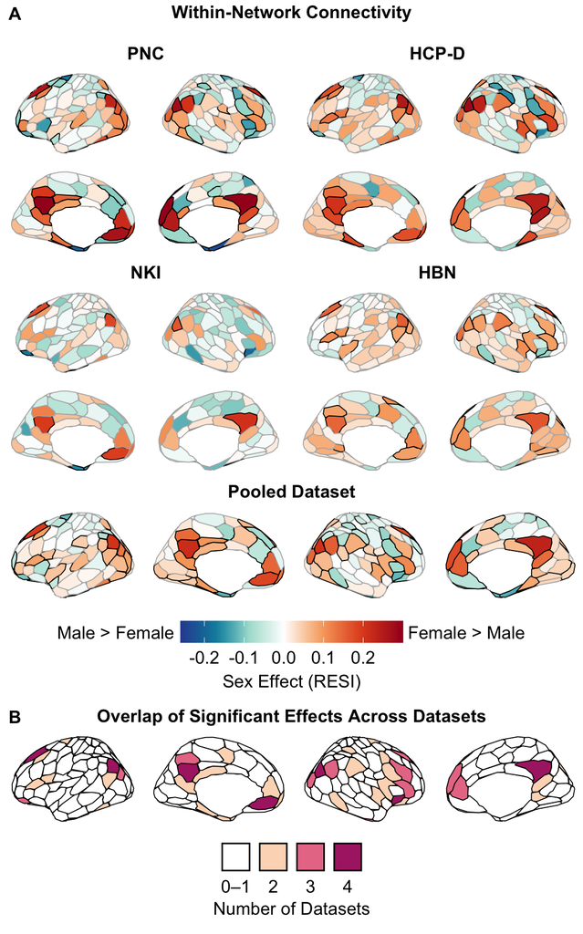

```r
WNC_plots_final
```

```r
#ggsave("/Users/audluo/Library/CloudStorage/Box-Box/Box_PhD_Land/PennLINC/sex_diff/sex_diff_manuscript/drafts/figures/fig3.tiff", plot = WNC_plots_final, width = 140, height = 224, units = "mm", dpi = 500,bg = "white")
```

### WNC count

```r
count_replication("WNC", "female")
```

```
## # A tibble: 3 × 5
##   measure direction k         n   pct
##   <chr>   <chr>     <chr> <int> <dbl>
## 1 WNC     female    2+       32    16
## 2 WNC     female    3+       16     8
## 3 WNC     female    4         6     3
```

### Regions showing significantly greater WNC in males than females in two or more datasets.

| Region | No. of datasets |
| --- | --- |
| RH_LimbicA_TempPole_4 | 4 |
| RH_SalVentAttnB_Ins_1 | 4 |
| LH_DefaultB_PFCv_2 | 3 |
| RH_LimbicA_TempPole_2 | 3 |
| LH_LimbicA_TempPole_1 | 2 |
| LH_LimbicA_TempPole_2 | 2 |
| LH_LimbicA_TempPole_3 | 2 |
| LH_SomMotA_1 | 2 |
| LH_SomMotA_6 | 2 |
| RH_ContA_PFCl_1 | 2 |
| RH_ContB_Temp_2 | 2 |
| RH_DorsAttnB_PostC_2 | 2 |
| RH_LimbicB_OFC_2 | 2 |
| RH_SalVentAttnA_PrC_1 | 2 |
| RH_SomMotA_8 | 2 |

# 4. Sex differences in network-level connectivity

```r
num_networks = 17
sex.main.PNC.networkpair.17 <- read.csv(sprintf("%1$s/%2$s/GAM/%3$s/%2$s_GAM_sex_maineffects_schaefer200x%4$s.csv", output_root, "PNC", "networkpair", num_networks))
sex.main.HCPD.networkpair.17 <- read.csv(sprintf("%1$s/%2$s/GAM/%3$s/%2$s_GAM_sex_maineffects_schaefer200x%4$s.csv", output_root, "HCPD", "networkpair", num_networks))
sex.main.NKI.networkpair.17 <- read.csv(sprintf("%1$s/%2$s/GAM/%3$s/%2$s_GAM_sex_maineffects_schaefer200x%4$s.csv", output_root, "NKI", "networkpair", num_networks))
sex.main.HBN.networkpair.17 <- read.csv(sprintf("%1$s/%2$s/GAM/%3$s/%2$s_GAM_sex_maineffects_schaefer200x%4$s.csv", output_root, "HBN", "networkpair", num_networks))
sex.main.all_datasets.networkpair.17 <- read.csv(sprintf("%1$s/%2$s/GAM/%3$s/%2$s_GAM_sex_maineffects_schaefer200x%4$s.csv", output_root, "all_datasets", "networkpair", num_networks))


# make two new columns identifying network 1 and network 2
sex.main.PNC.networkpair.17<- sex.main.PNC.networkpair.17%>%
  mutate(network1 = str_extract(region, "[[:alpha:]]+"), network2=str_extract(region, "(?<=_).*"))
sex.main.HCPD.networkpair.17<- sex.main.HCPD.networkpair.17%>%
  mutate(network1 = str_extract(region, "[[:alpha:]]+"), network2=str_extract(region, "(?<=_).*"))
sex.main.NKI.networkpair.17<- sex.main.NKI.networkpair.17%>%
  mutate(network1 = str_extract(region, "[[:alpha:]]+"), network2=str_extract(region, "(?<=_).*"))
sex.main.HBN.networkpair.17<- sex.main.HBN.networkpair.17%>%
  mutate(network1 = str_extract(region, "[[:alpha:]]+"), network2=str_extract(region, "(?<=_).*"))
sex.main.all_datasets.networkpair.17<- sex.main.all_datasets.networkpair.17%>%
  mutate(network1 = str_extract(region, "[[:alpha:]]+"), network2=str_extract(region, "(?<=_).*"))

# fdr correction on non-duplicated pairs only and sorts pairs
sex.main.PNC.networkpair.17<- prep_networkpair_df(sex.main.PNC.networkpair.17, "networkpair", "sex", "PNC")
```

```
## [1] "PNC: 76 regions (49.67 percent) show a significant association between networkpair and sex"
```

```r
sex.main.HCPD.networkpair.17<- prep_networkpair_df(sex.main.HCPD.networkpair.17,  "networkpair", "sex", "HCPD")
```

```
## [1] "HCPD: 43 regions (28.1 percent) show a significant association between networkpair and sex"
```

```r
sex.main.NKI.networkpair.17<- prep_networkpair_df(sex.main.NKI.networkpair.17,  "networkpair", "sex", "NKI")
```

```
## [1] "NKI: 6 regions (3.92 percent) show a significant association between networkpair and sex"
```

```r
sex.main.HBN.networkpair.17<- prep_networkpair_df(sex.main.HBN.networkpair.17,  "networkpair", "sex", "HBN")
```

```
## [1] "HBN: 31 regions (20.26 percent) show a significant association between networkpair and sex"
```

```r
sex.main.all_datasets.networkpair.17<- prep_networkpair_df(sex.main.all_datasets.networkpair.17,  "networkpair", "sex", "All datasets")
```

```
## [1] "All datasets: 95 regions (62.09 percent) show a significant association between networkpair and sex"
```

```r
resi.PNC.networkpair <- read.csv(file.path(root, "covariate_analyses", "sex_diff", "output", "PNC", "resi", "networkpair", "PNC_resiPEse_Th1_sex_maineffects_schaefer200x17.csv")) %>% rename(RESI = RESI_Xinyu) %>% select(region, RESI)
resi.HCPD.networkpair <- read.csv(file.path(root, "covariate_analyses", "sex_diff", "output", "HCPD", "resi", "networkpair", "HCPD_resiPEse_Th1_sex_maineffects_schaefer200x17.csv")) %>% rename(RESI = RESI_Xinyu) %>% select(region, RESI)
resi.NKI.networkpair <- read.csv(file.path(root, "covariate_analyses", "sex_diff", "output", "NKI", "resi", "networkpair", "NKI_resiPEse_Th1_sex_maineffects_schaefer200x17.csv")) %>% rename(RESI = RESI_Xinyu) %>% select(region, RESI)
resi.HBN.networkpair <- read.csv(file.path(root, "covariate_analyses", "sex_diff", "output", "HBN", "resi", "networkpair", "HBN_resiPEse_Th1_sex_maineffects_schaefer200x17.csv")) %>% rename(RESI = RESI_Xinyu) %>% select(region, RESI)
resi.all_datasets.networkpair <- read.csv(file.path(root, "covariate_analyses", "sex_diff", "output", "all_datasets", "resi", "networkpair", "all_datasets_resiPEse_Th1_sex_maineffects_schaefer200x17.csv")) %>% rename(RESI = RESI_Xinyu) %>% select(region, RESI)

sex.main.PNC.networkpair.17 <- merge(sex.main.PNC.networkpair.17, resi.PNC.networkpair)
sex.main.NKI.networkpair.17 <- merge(sex.main.NKI.networkpair.17, resi.NKI.networkpair)
sex.main.HCPD.networkpair.17 <- merge(sex.main.HCPD.networkpair.17, resi.HCPD.networkpair)
sex.main.HBN.networkpair.17 <- merge(sex.main.HBN.networkpair.17, resi.HBN.networkpair)
sex.main.all_datasets.networkpair.17 <- merge(sex.main.all_datasets.networkpair.17, resi.all_datasets.networkpair)
```

```r
# plot each dataset
networkpair_resi_PNC <- annotate_figure(
  make_networkpair17_plot(sex.main.PNC.networkpair.17, dataset = "PNC", ylim1 = -0.3, ylim2 = 0.3, fontsize = 7, fontsize_label = 2.6, measure = "RESI"))

networkpair_resi_HCPD <- annotate_figure(
  make_networkpair17_plot(sex.main.HCPD.networkpair.17, dataset = "HCP-D", ylim1 = -0.3, ylim2 = 0.3, fontsize = 7, fontsize_label = 2.6, measure = "RESI"))

networkpair_resi_NKI <- annotate_figure(
  make_networkpair17_plot(sex.main.NKI.networkpair.17, dataset = "NKI", ylim1 = -0.3, ylim2 = 0.3, fontsize = 7, fontsize_label = 2.6, measure = "RESI"))

networkpair_resi_HBN <- annotate_figure(
  make_networkpair17_plot(sex.main.HBN.networkpair.17, dataset = "HBN", ylim1 = -0.3, ylim2 = 0.3, fontsize = 7, fontsize_label = 2.6, measure = "RESI"))

networkpair_resi_all_datasets_plot_tmp <- annotate_figure(
  make_networkpair17_plot(sex.main.all_datasets.networkpair.17, dataset = "Pooled Dataset", ylim1 = -0.3, ylim2 = 0.3, fontsize = 7, fontsize_label = 2.6, measure = "RESI"))

networkpair_row1 <- plot_grid(NULL, networkpair_resi_PNC, NULL, networkpair_resi_HCPD, ncol = 4,
                              rel_widths = c(0.03, 1, 0.06, 1))
networkpair_row2 <- plot_grid(NULL, networkpair_resi_NKI, NULL, networkpair_resi_HBN, ncol = 4,
                              rel_widths = c(0.03, 1, 0.06, 1))
networkpair_datasets_plot <- plot_grid(networkpair_row1, networkpair_row2, nrow = 2)

# legend
ylim1 = -0.3
ylim2 = 0.3
p <- ggplot() +
    geom_brain(data = sex.main.HBN.BNC, atlas = schaefer17_200,
               mapping=aes(fill=RESI),
               show.legend=TRUE) +
     scale_fill_gradientn(colours = red_teal_white(256),
                          values = scales::rescale(c(ylim1, 0, ylim2)), limits = c(ylim1, ylim2), oob = squish, na.value = "white") +
    theme_void()  +
    theme(legend.title = element_blank(),
          legend.text = element_text(size = 10),
        legend.position = "bottom",
        legend.box = "horizontal",
        legend.key.height = unit(0.4, 'cm'),
        legend.key.width = unit(1, 'cm'),
        plot.margin = unit(c(0, 0.5, 0, 0.5), "cm"))

legend_tmp <- get_legend(p)
```

```r
# overlap of datasets:
df_list_networkpair <- list(
  PNC  = sex.main.PNC.networkpair.17[, c("region", "cov.pvalue.fdr")] |> rename(p_PNC = cov.pvalue.fdr),
  HCPD = sex.main.HCPD.networkpair.17[, c("region", "cov.pvalue.fdr")] |> rename(p_HCPD = cov.pvalue.fdr),
  NKI  = sex.main.NKI.networkpair.17[,  c("region", "cov.pvalue.fdr")] |> rename(p_NKI = cov.pvalue.fdr),
  HBN  = sex.main.HBN.networkpair.17[,  c("region", "cov.pvalue.fdr")] |> rename(p_HBN = cov.pvalue.fdr)
)

sex.main.overlap.networkpair <- Reduce(function(x, y) full_join(x, y, by = "region"), df_list_networkpair)

sex.main.overlap.networkpair <- sex.main.overlap.networkpair %>%
  mutate(
    signif_count = rowSums(across(starts_with("p_")) < 0.05, na.rm = TRUE),
    signif_count_factor = factor(
      signif_count,
      levels = 0:4,
      labels = c("0", "1", "2", "3", "4")
    ),
    signif_greater_than_one = ifelse(signif_count > 1, "1", "0")
  )

sex.main.overlap.networkpair_plot_df <- sex.main.overlap.networkpair %>%
  mutate(
    network1 = str_extract(region, "^[[:alpha:]]+"),
    network2 = str_extract(region, "(?<=_).*")
  )


# overlap legend
legend_plot <- ggplot(data.frame(overlap = factor(names(count_colors_legend),
                                                  levels = names(count_colors_legend))),
                      aes(x = overlap, fill = overlap)) +
  geom_bar() +
  scale_fill_manual(values = count_colors_legend,
                    guide = guide_legend(direction = "horizontal",
                                         label.position = "bottom",
                                         override.aes = list(colour = "black", size = 1))) +
  theme_void() +
  theme(
    legend.title = element_blank(),
    legend.text  = element_text(size = 10),
    legend.key.size = unit(0.7, "cm"),
    legend.position = "bottom"
  )

overlap_legend_tmp <- get_legend(legend_plot)
networkpair_resi_overlap_plot_tmp <-  plot_networkpair_overlap(sex.main.overlap.networkpair_plot_df)
```

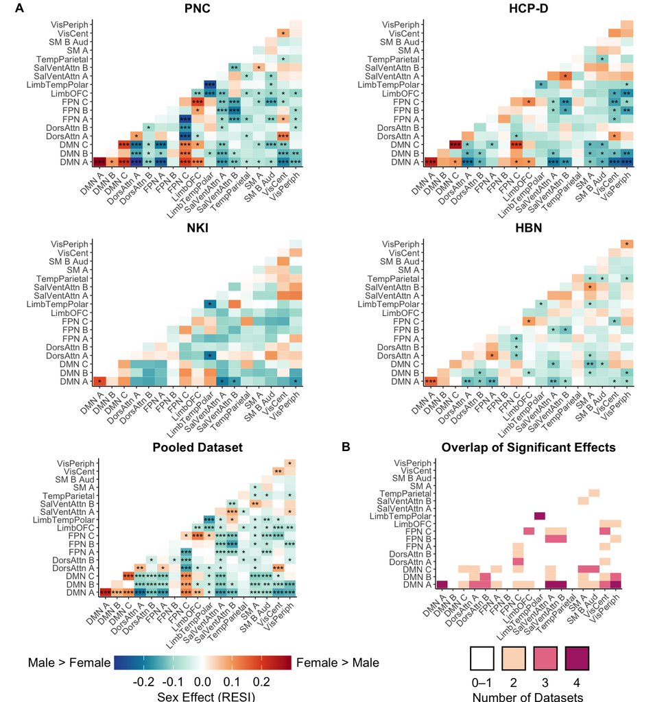

```r
# pnc, nki, hcpd, hbn
networkpair_resi_row1 <- networkpair_datasets_plot

# all datasets + legend
legend <- ggdraw() +
  draw_plot(legend_tmp, x = 0.23, y = 0, width = 0.3, height = 1) +
  draw_label("Male > Female", x = -0.53, y = 3.68, size = 10, hjust = 0) +
  draw_label("Female > Male", x = 1.3, y = 3.68, size = 10, hjust = 1)

resi_legend <- annotate_figure(plot_grid(
  NULL, legend,
  ncol = 2,
  rel_widths = c(0.47, 0.75)), bottom = text_grob("Sex Effect (RESI)", size = 10, y = -0.3, x = 0.63))
networkpair_resi_all_datasets_plot <- plot_grid(networkpair_resi_all_datasets_plot_tmp, NULL, resi_legend, NULL,
                                                nrow = 4, rel_heights = c(1, 0.1, 0.1,  0.05))
# overlap + legend
overlap_legend <- annotate_figure(plot_grid(
  NULL, overlap_legend_tmp,
  ncol = 2,
  rel_widths = c(0.2, 0.75)), bottom = text_grob("Number of Datasets", size = 10, y = -0.3, x = 0.6))
networkpair_overlap_plot <- plot_grid(networkpair_resi_overlap_plot_tmp, NULL, overlap_legend, NULL,
                                      nrow = 4, rel_heights = c(1, 0.1, 0.15,  0.05))



networkpair_resi_row2 <- plot_grid(NULL, networkpair_resi_all_datasets_plot, NULL, networkpair_overlap_plot, ncol = 4,
                              rel_widths = c(0.03, 1, 0.06, 1))

networkpair_plot_final <- plot_grid(networkpair_resi_row1, networkpair_resi_row2, nrow = 2, rel_heights = c(1.2, 0.72))

networkpair_plot_final <- ggdraw(networkpair_plot_final) +
  draw_label("A", x = 0.03, y = 0.989, fontface = "bold", size = 10) +
  draw_label("B", x = 0.53, y = 0.364, fontface = "bold", size = 10)

networkpair_plot_final
```

```r
#ggsave("/Users/audluo/Library/CloudStorage/Box-Box/Box_PhD_Land/PennLINC/sex_diff/sex_diff_manuscript/drafts/figures/fig4.tiff", plot = networkpair_plot_final, width = 184, height = 198, units = "mm", dpi = 500, bg = "white")
```

```r
networkpair_list <- list(
  PNC = sex.main.PNC.networkpair.17, NKI = sex.main.NKI.networkpair.17,
  `HCP-D` = sex.main.HCPD.networkpair.17, HBN = sex.main.HBN.networkpair.17,
  `Pooled Dataset` = sex.main.all_datasets.networkpair.17
)

pretty_network <- c(
  defaultA = "default mode A", defaultB = "default mode B", defaultC = "default mode C",
  frontoparietalControlA = "control A", frontoparietalControlB = "control B", frontoparietalControlC = "control C",
  dorsalAttentionA = "dorsal attention A", dorsalAttentionB = "dorsal attention B",
  salienceVentralAttentionA = "salience/ventral attention A", salienceVentralAttentionB = "salience/ventral attention B",
  limbicOrbitofrontal = "limbic orbitofrontal", limbicTemporopolar = "limbic temporal pole",
  somatomotorA = "somatomotor A", somatomotorB = "somatomotor B",
  visualCentral = "visual central", visualPeripheral = "visual peripheral", temporalParietal = "temporal parietal"
)

pretty_pair <- function(region) {
  nets <- strsplit(region, "_")[[1]]
  nets <- ifelse(nets %in% names(pretty_network), unname(pretty_network[nets]), nets)
  if (nets[1] == nets[2]) paste(nets[1], "within") else paste(nets[1], "with", nets[2])
}

# FDR-corrected p-value: 3 decimals, or scientific notation below 0.001
fmt_p <- function(p) ifelse(p < 0.001, formatC(p, format = "e", digits = 1), sprintf("%.3f", p))

fmt <- function(region, resi, p) {
  sprintf("%s (RESI = %.2f, Q<sub>FDR</sub> = %s)", pretty_pair(region), resi, fmt_p(p))
}

summarise_dataset <- function(df, dataset_name) {
  sig <- df %>% filter(significant_status == "Sig")
  female <- sig %>% filter(RESI > 0) %>% arrange(desc(RESI)) %>% mutate(rank = row_number())
  male <- sig %>% filter(RESI < 0) %>% arrange(RESI)

  female_cell <- fmt(female$region[1], female$RESI[1], female$cov.pvalue.fdr[1])
  dmnA <- female %>% filter(region == "defaultA_defaultA")

  if (female$region[1] != "defaultA_defaultA" && nrow(dmnA) == 1)
    female_cell <- paste0(
      female_cell, "; ", pretty_pair(dmnA$region),
      sprintf(" (RESI = %.2f, Q<sub>FDR</sub> = %s; rank %d)", dmnA$RESI, fmt_p(dmnA$cov.pvalue.fdr), dmnA$rank)
    )

  tibble(
    Dataset = dataset_name,
    `Female > Male` = female_cell,
    `Male > Female` = fmt(male$region[1], male$RESI[1], male$cov.pvalue.fdr[1])
  )
}

networkpair_summary <- imap_dfr(networkpair_list, summarise_dataset)

networkpair_summary %>%
  kbl(caption = "Largest significant sex effects (RESI) on network-pair connectivity, with FDR-corrected p-values",
      col.names = c("Dataset", "Female > Male", "Male > Female"), align = c("l", "l", "l"), booktabs = TRUE, escape = FALSE) %>%
  kable_styling(bootstrap_options = c("striped", "hover"), full_width = FALSE, position = "center", font_size = 20) %>%
  column_spec(1, bold = TRUE, width = "8em") %>%
  column_spec(2, width = "28em") %>%
  column_spec(3, width = "28em") %>%
  row_spec(0, bold = TRUE)
```

Largest significant sex effects (RESI) on network-pair connectivity, with FDR-corrected p-values

| Dataset | Female > Male | Male > Female |
| --- | --- | --- |
| PNC | default mode A within (RESI = 0.33, Q<sub>FDR</sub> = 7.3e-26) | default mode A with dorsal attention A (RESI = -0.30, Q<sub>FDR</sub> = 6.7e-23) |
| NKI | default mode A within (RESI = 0.18, Q<sub>FDR</sub> = 0.014) | dorsal attention A with limbic temporal pole (RESI = -0.20, Q<sub>FDR</sub> = 0.006) |
| HCP-D | default mode C within (RESI = 0.26, Q<sub>FDR</sub> = 2.4e-08); default mode A within (RESI = 0.24, Q<sub>FDR</sub> = 1.5e-07; rank 2) | default mode A with visual peripheral (RESI = -0.25, Q<sub>FDR</sub> = 2.6e-08) |
| HBN | default mode A within (RESI = 0.16, Q<sub>FDR</sub> = 2.9e-05) | default mode A with control A (RESI = -0.14, Q<sub>FDR</sub> = 2.8e-04) |
| Pooled Dataset | default mode A within (RESI = 0.23, Q<sub>FDR</sub> = 1.2e-38) | default mode A with dorsal attention A (RESI = -0.21, Q<sub>FDR</sub> = 1.6e-30) |

```r
partners <- c("dorsalAttentionA", "dorsalAttentionB",
              "salienceVentralAttentionA", "salienceVentralAttentionB",
              "visualCentral", "visualPeripheral", "frontoparietalControlA")

dmnA_partner_table <- imap_dfr(networkpair_list, function(df, dataset_name) {
  df %>%
    mutate(net1 = sub("_.*", "", region), net2 = sub(".*_", "", region)) %>%
    filter((net1 == "defaultA" & net2 %in% partners) | (net2 == "defaultA" & net1 %in% partners)) %>%
    transmute(
      Dataset = dataset_name,
      Partner = ifelse(net1 == "defaultA", net2, net1),
      cell = ifelse(
        significant_status == "Sig",
        sprintf("%.2f<br>(Q<sub>FDR</sub> = %s)", RESI, fmt_p(cov.pvalue.fdr)),
        "n.s."
      )
    )
}) %>%
  mutate(Partner = factor(Partner, levels = partners, labels = unname(pretty_network[partners]))) %>%
  arrange(Partner) %>%
  pivot_wider(names_from = Dataset, values_from = cell)

dmnA_partner_table %>%
  kbl(caption = "Sex effects (RESI) and FDR-corrected p-values for connectivity between default mode A and attention, visual, and control A networks (negative = male > female; n.s. = not significant)",
      align = c("l", rep("c", length(networkpair_list))), booktabs = TRUE, escape = FALSE) %>%
  kable_styling(bootstrap_options = c("striped", "hover"), full_width = FALSE, position = "center", font_size = 20) %>%
  column_spec(1, bold = TRUE) %>%
  row_spec(0, bold = TRUE)
```

Sex effects (RESI) and FDR-corrected p-values for connectivity between default mode A and attention, visual, and control A networks (negative = male > female; n.s. = not significant)

| Partner | PNC | NKI | HCP-D | HBN | Pooled Dataset |
| --- | --- | --- | --- | --- | --- |
| dorsal attention A | -0.30 (Q<sub>FDR</sub> = 6.7e-23) | n.s. | -0.21 (Q<sub>FDR</sub> = 7.3e-06) | -0.13 (Q<sub>FDR</sub> = 6.7e-04) | -0.21 (Q<sub>FDR</sub> = 1.6e-30) |
| dorsal attention B | -0.11 (Q<sub>FDR</sub> = 7.1e-04) | n.s. | -0.14 (Q<sub>FDR</sub> = 0.006) | -0.11 (Q<sub>FDR</sub> = 0.003) | -0.12 (Q<sub>FDR</sub> = 6.7e-11) |
| salience/ventral attention A | -0.16 (Q<sub>FDR</sub> = 1.7e-07) | -0.20 (Q<sub>FDR</sub> = 0.006) | -0.20 (Q<sub>FDR</sub> = 1.6e-05) | -0.13 (Q<sub>FDR</sub> = 8.6e-04) | -0.16 (Q<sub>FDR</sub> = 2.9e-18) |
| salience/ventral attention B | -0.12 (Q<sub>FDR</sub> = 2.0e-04) | -0.16 (Q<sub>FDR</sub> = 0.034) | -0.17 (Q<sub>FDR</sub> = 4.5e-04) | -0.09 (Q<sub>FDR</sub> = 0.013) | -0.12 (Q<sub>FDR</sub> = 2.5e-11) |
| visual central | -0.19 (Q<sub>FDR</sub> = 8.8e-10) | n.s. | -0.23 (Q<sub>FDR</sub> = 8.1e-07) | -0.08 (Q<sub>FDR</sub> = 0.047) | -0.15 (Q<sub>FDR</sub> = 2.1e-17) |
| visual peripheral | -0.13 (Q<sub>FDR</sub> = 4.9e-05) | -0.17 (Q<sub>FDR</sub> = 0.034) | -0.25 (Q<sub>FDR</sub> = 2.6e-08) | -0.09 (Q<sub>FDR</sub> = 0.016) | -0.14 (Q<sub>FDR</sub> = 5.8e-15) |
| control A | -0.24 (Q<sub>FDR</sub> = 2.8e-15) | n.s. | n.s. | -0.14 (Q<sub>FDR</sub> = 2.8e-04) | -0.16 (Q<sub>FDR</sub> = 6.5e-19) |

```r
male_consistent_pairs <- c("defaultA_salienceVentralAttentionA", "defaultA_salienceVentralAttentionB",
                           "defaultA_visualPeripheral", "limbicTemporopolar_limbicTemporopolar")

male_long <- imap_dfr(networkpair_list[c("PNC", "NKI", "HCP-D", "HBN")], function(df, dataset_name) {
  df %>%
    filter(region %in% male_consistent_pairs) %>%
    mutate(Dataset = dataset_name,
           cell = sprintf("%.2f (Q<sub>FDR</sub> = %s)", RESI, fmt_p(cov.pvalue.fdr))) %>%
    select(region, Dataset, RESI, cov.pvalue.fdr, cell)
})
```

# 5. Sex differences in edge-level connectivity vary with hierarchical span of functional connections

```r
# edge gam output
sex.main.PNC.edge <- read.csv(sprintf("%1$s/%2$s/GAM/%3$s/%2$s_GAM_sex_maineffects_schaefer200x17.csv", output_root, "PNC", "edge"))
sex.main.HCPD.edge <- read.csv(sprintf("%1$s/%2$s/GAM/%3$s/%2$s_GAM_sex_maineffects_schaefer200x17.csv", output_root, "HCPD", "edge"))
sex.main.NKI.edge <- read.csv(sprintf("%1$s/%2$s/GAM/%3$s/%2$s_GAM_sex_maineffects_schaefer200x17.csv", output_root, "NKI", "edge"))
sex.main.HBN.edge <- read.csv(sprintf("%1$s/%2$s/GAM/%3$s/%2$s_GAM_sex_maineffects_schaefer200x17.csv", output_root, "HBN", "edge"))
sex.main.all_datasets.edge <- read.csv(sprintf("%1$s/%2$s/GAM/%3$s/%2$s_GAM_sex_maineffects_schaefer200x17.csv", output_root, "all_datasets", "edge"))

# resi
resi.PNC.edge <- read.csv(file.path(root, "covariate_analyses", "sex_diff", "output", "PNC", "resi", "edge", "PNC_t2S_sex_maineffects_schaefer200x17.csv"))
resi.HCPD.edge <- read.csv(file.path(root, "covariate_analyses", "sex_diff", "output", "HCPD", "resi", "edge", "HCPD_t2S_sex_maineffects_schaefer200x17.csv"))
resi.NKI.edge <- read.csv(file.path(root, "covariate_analyses", "sex_diff", "output", "NKI", "resi", "edge", "NKI_t2S_sex_maineffects_schaefer200x17.csv"))
resi.HBN.edge <- read.csv(file.path(root, "covariate_analyses", "sex_diff", "output", "HBN", "resi", "edge", "HBN_t2S_sex_maineffects_schaefer200x17.csv"))
resi.all_datasets.edge <- read.csv(file.path(root, "covariate_analyses", "sex_diff", "output", "all_datasets", "resi", "edge", "all_datasets_t2S_sex_maineffects_schaefer200x17.csv"))

# merge resi
sex.main.PNC.edge <- merge(sex.main.PNC.edge, resi.PNC.edge, by = "region", all.x = TRUE, sort = FALSE)
sex.main.HCPD.edge <- merge(sex.main.HCPD.edge, resi.HCPD.edge, by = "region", all.x = TRUE, sort = FALSE)
sex.main.NKI.edge <- merge(sex.main.NKI.edge, resi.NKI.edge, by = "region", all.x = TRUE, sort = FALSE)
sex.main.HBN.edge <- merge(sex.main.HBN.edge, resi.HBN.edge, by = "region", all.x = TRUE, sort = FALSE)
sex.main.all_datasets.edge <- merge(sex.main.all_datasets.edge, resi.all_datasets.edge, by = "region", all.x = TRUE, sort = FALSE)

# load vector of differences in S-A rank between the 2 regions connecting each edge
SA.diff <- read.csv(file.path(root, "atlases", "edge", "SA.diff_schaefer200x17.csv"))

# make df for plotting (and do FDR correction)
double.PNC <- make_double_df(sex.main.PNC.edge, "edge", "sex", "PNC")
```

```
## [1] "PNC: 6947 regions (34.91 percent) show a significant association between edge and sex"
```

```r
double.HCPD <- make_double_df(sex.main.HCPD.edge, "edge", "sex", "HCPD")
```

```
## [1] "HCPD: 3341 regions (16.79 percent) show a significant association between edge and sex"
```

```r
double.NKI <- make_double_df(sex.main.NKI.edge, "edge", "sex", "NKI")
```

```
## [1] "NKI: 571 regions (2.87 percent) show a significant association between edge and sex"
```

```r
double.HBN <- make_double_df(sex.main.HBN.edge, "edge", "sex", "HBN")
```

```
## [1] "HBN: 1960 regions (9.85 percent) show a significant association between edge and sex"
```

```r
double.all_datasets <- make_double_df(sex.main.all_datasets.edge, "edge", "sex", "All datasets")
```

```
## [1] "All datasets: 9552 regions (48 percent) show a significant association between edge and sex"
```

```r
# load spin test results
PNC_edges_spin <- readRDS(sprintf("%1$s/%2$s/spin_test/edge/SA_edges_schaefer200x17_spin_test_results.RData", output_root, "PNC"))
HCPD_edges_spin <- readRDS(sprintf("%1$s/%2$s/spin_test/edge/SA_edges_schaefer200x17_spin_test_results.RData", output_root, "HCPD"))
NKI_edges_spin <- readRDS(sprintf("%1$s/%2$s/spin_test/edge/SA_edges_schaefer200x17_spin_test_results.RData", output_root, "NKI"))
HBN_edges_spin <- readRDS(sprintf("%1$s/%2$s/spin_test/edge/SA_edges_schaefer200x17_spin_test_results.RData", output_root, "HBN"))
all_datasets_edges_spin <- readRDS(sprintf("%1$s/%2$s/spin_test/edge/SA_edges_schaefer200x17_spin_test_results.RData", output_root, "all_datasets"))
```

We modeled the sex-effect map (RESI) across edges using tensor product smooth:

$$edge.sex.effect \sim
te(SArank_{parcel1}, SArank_{parcel2})$$

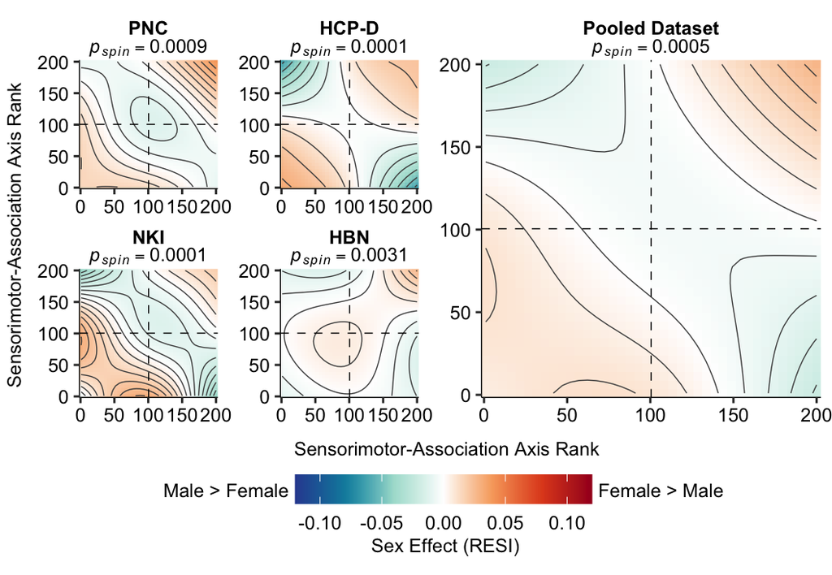

```r
# plot surfaces
PNC_surf_plot <- make_surface_plot(double.PNC, dataset = "PNC", measure = "RESI", ylim1 = -0.12, ylim2  = 0.12,
                                   p_label = bquote(italic(p[spin]) == .(format(round(PNC_edges_spin$p_values$R2, 4),
                                                                                scientific = FALSE)))) + coord_cartesian(clip = "off")
HCPD_surf_plot <-  make_surface_plot(double.HCPD, dataset = "HCP-D", measure = "RESI", ylim1 = -0.12, ylim2  = 0.12,
                                   p_label = bquote(italic(p[spin]) == .(format(round(HCPD_edges_spin$p_values$R2, 4),
                                                                                scientific = FALSE)))) + coord_cartesian(clip = "off")
NKI_surf_plot <-  make_surface_plot(double.NKI, dataset = "NKI", measure = "RESI", ylim1 = -0.12, ylim2  = 0.12,
                                   p_label = bquote(italic(p[spin]) == .(format(round(NKI_edges_spin$p_values$R2, 4),
                                                                                scientific = FALSE)))) + coord_cartesian(clip = "off")
HBN_surf_plot <-  make_surface_plot(double.HBN, dataset = "HBN", measure = "RESI", ylim1 = -0.12, ylim2  = 0.12,
                                   p_label = bquote(italic(p[spin]) == .(format(round(HBN_edges_spin$p_values$R2, 4),
                                                                                 scientific = FALSE)))) + coord_cartesian(clip = "off")

row1 <- ggdraw() +
  draw_plot(HCPD_surf_plot, x = 0.5, y = 0, width = 0.5, height = 1) + # want HCPD drawn first for formatting issues
  draw_plot(PNC_surf_plot, x = 0, y = 0, width = 0.5, height = 1)

row2 <- ggdraw() +
  draw_plot(HBN_surf_plot, x = 0.5, y = 0, width = 0.5, height = 1) +
  draw_plot(NKI_surf_plot, x = 0, y = 0, width = 0.5, height = 1)

datasets_surf_plots <- plot_grid(row1, NULL, row2, ncol = 1, nrow = 3, rel_heights = c(1, 0.1, 1))


all_datasets_surf_plot <-  make_surface_plot(double.all_datasets, dataset = "Pooled Dataset", measure = "RESI", ylim1 = -0.12, ylim2  = 0.12,
                                             p_label = bquote(italic(p[spin]) == .(format(round(all_datasets_edges_spin$p_values$R2, 4),
                                                                                          scientific = FALSE)))) + coord_cartesian(clip = "off")

# make legend
ylim1 = -0.12
ylim2 = 0.12
g2 <- gam(RESI ~ te(parcel2_SA,parcel1_SA,k=3), data = double.PNC)

surface.plot.fig <- gg_tensor(g2) + theme_classic() +
    theme(
      axis.title.x=element_blank(),
      axis.title.y=element_blank(),
      axis.line = element_line(color = "black"),
      axis.text=element_text(size=24, color = "black")) +
     scale_fill_gradientn(colours = red_teal_white(256),
                          values = scales::rescale(c(ylim1, 0, ylim2)), limits = c(ylim1, ylim2), oob = squish, na.value = "white") +
  geom_vline(xintercept = mean(range(double.PNC$parcel1_SA)),
               linetype='dashed',size=1) +
    geom_hline(yintercept = mean(range(double.PNC$parcel1_SA)),
               linetype='dashed',size=1) +
    theme(legend.position='bottom',
          legend.key.height = unit(0.5, 'cm'),
          legend.key.width = unit(1, 'cm'),
          legend.title = element_blank(),
          legend.text = element_text(size = 9),
          strip.background = element_blank(),
          plot.margin = margin(0, 0, 0, 0, "cm"),
          plot.title = element_text(size=10, hjust=0.5))

legend <- get_legend(surface.plot.fig)

legend <- ggdraw() +
  draw_plot(legend, x = 0.23, y = 0, width = 0.54, height = 1) +
  draw_label("Male > Female", x = 0.14, y = 0.66, size = 9, hjust = 0) +
  draw_label("Female > Male", x = 0.86, y = 0.66, size = 9, hjust = 1)

legend_formatted <- plot_grid(NULL, legend, ncol = 2, rel_widths = c(0.07, 1))

# combine plots
combined_surf_plots <- annotate_figure(ggdraw() +
  draw_plot(all_datasets_surf_plot, x = 0.5, y = 0, width = 0.5, height = 1) +
  draw_plot(datasets_surf_plots, x = 0, y = 0, width = 0.5, height = 1),
                                       left = text_grob("Sensorimotor-Association Axis Rank", size = 9, x = 0.5, rot = 90),
                                       bottom = text_grob("Sensorimotor-Association Axis Rank", size = 9, x = 0.52, y = 0))

final_surf_plots <- plot_grid(NULL, combined_surf_plots, NULL, legend_formatted, nrow = 4, rel_heights = c(0.05, 1, 0.03, 0.2))
final_surf_plots <- annotate_figure(final_surf_plots,
                bottom = text_grob("Sex Effect (RESI)", size = 9, x = 0.535, y = 1.05))

final_surf_plots
```

```r
#ggsave("/Users/audluo/Library/CloudStorage/Box-Box/Box_PhD_Land/PennLINC/sex_diff/sex_diff_manuscript/drafts/figures/fig5.tiff", plot = final_surf_plots, width = 140, height = 96.9, units = "mm", dpi = 500, bg = "white")
```

# 6. Females exhibit greater differentiation between association networks and lower-order networks along the principal gradient.

```r
between_net_disp_PNC <- read.csv(sprintf("%s/covariate_analyses/sex_diff/output/%s/gradient_dispersion/resi/%s_resi_sex_dispersion_between_network.csv", root, "PNC", "PNC")) %>% rename(RESI = RESI_Xinyu)
between_net_disp_NKI <- read.csv(sprintf("%s/covariate_analyses/sex_diff/output/%s/gradient_dispersion/resi/%s_resi_sex_dispersion_between_network.csv", root, "NKI", "NKI")) %>% rename(RESI = RESI_Xinyu)
between_net_disp_HCPD <- read.csv(sprintf("%s/covariate_analyses/sex_diff/output/%s/gradient_dispersion/resi/%s_resi_sex_dispersion_between_network.csv", root, "HCPD", "HCPD")) %>% rename(RESI = RESI_Xinyu)
between_net_disp_HBN <- read.csv(sprintf("%s/covariate_analyses/sex_diff/output/%s/gradient_dispersion/resi/%s_resi_sex_dispersion_between_network.csv", root, "HBN", "HBN")) %>% rename(RESI = RESI_Xinyu)
between_net_disp_all_datasets <- read.csv(sprintf("%s/covariate_analyses/sex_diff/output/%s/gradient_dispersion/resi/%s_resi_sex_dispersion_between_network.csv", root, "all_datasets", "all_datasets")) %>% rename(RESI = RESI_Xinyu)
```

```r
disp_list <- list(
  PNC = between_net_disp_PNC, NKI = between_net_disp_NKI,
  `HCP-D` = between_net_disp_HCPD, HBN = between_net_disp_HBN,
  `Pooled Dataset` = between_net_disp_all_datasets
)

for (ds in names(disp_list)) {
  df <- disp_list[[ds]]
  n_total <- nrow(df)
  n_sig   <- sum(df$p_fdr < 0.05, na.rm = TRUE)
  print(sprintf("%s: %d of %d network pairs (%.0f percent) show a significant sex difference in between-network dispersion",
                ds, n_sig, n_total, 100 * n_sig / n_total))
}
```

```
## [1] "PNC: 59 of 136 network pairs (43 percent) show a significant sex difference in between-network dispersion"
## [1] "NKI: 22 of 136 network pairs (16 percent) show a significant sex difference in between-network dispersion"
## [1] "HCP-D: 65 of 136 network pairs (48 percent) show a significant sex difference in between-network dispersion"
## [1] "HBN: 8 of 136 network pairs (6 percent) show a significant sex difference in between-network dispersion"
## [1] "Pooled Dataset: 89 of 136 network pairs (65 percent) show a significant sex difference in between-network dispersion"
```

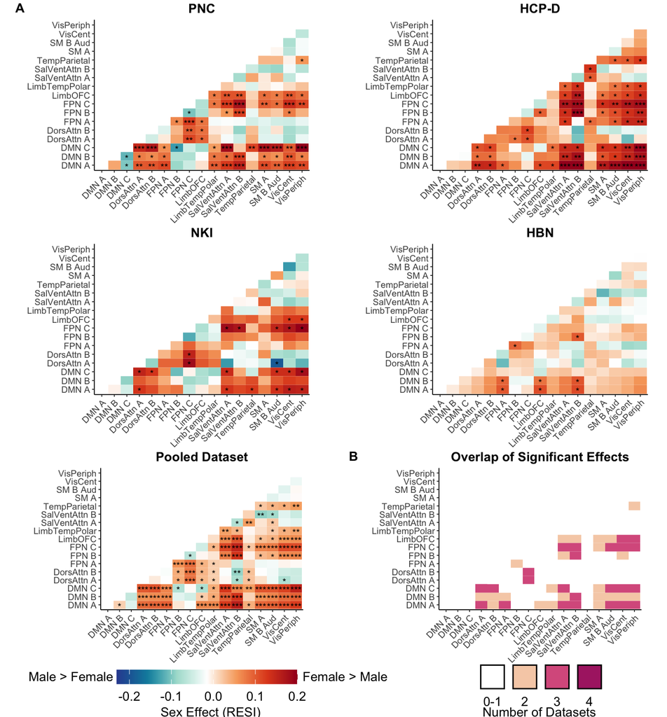

```r
 # -------------------- Individual datasets --------------------
between_PNC <- plot_between_dispersion("PNC", "PNC")
between_NKI <- plot_between_dispersion("NKI", "NKI")
between_HCPD <- plot_between_dispersion("HCPD", "HCP-D")
between_HBN <- plot_between_dispersion("HBN", "HBN")

between_row1 <- plot_grid(NULL, between_PNC, NULL, between_HCPD, ncol = 4, rel_widths = c(0.03, 1, 0.06, 1))
between_row2 <- plot_grid(NULL, between_NKI, NULL, between_HBN, ncol = 4, rel_widths = c(0.03, 1, 0.06, 1))
between_datasets_plot <- plot_grid(between_row1, between_row2, nrow = 2)

# -------------------- Pooled dataset + overlap --------------------
between_all <- plot_between_dispersion("all_datasets", "Pooled Dataset")
between_overlap_tmp <- plot_between_overlap()

# -------------------- RESI legend --------------------
resi_legend_plot <- ggplot(data.frame(x = 1, y = 1, z = 0), aes(x, y, fill = z)) +
  geom_tile() +
  scale_fill_gradientn(colours = red_teal_white(256), values = scales::rescale(c(-0.2, 0, 0.2)), limits = c(-0.23, 0.2), oob = squish, name = NULL) +
  theme_void() +
  theme(legend.position = "bottom", legend.text = element_text(size = 10), legend.key.height = unit(0.4, "cm"),
        legend.key.width = unit(1, "cm"))

resi_legend_tmp <- get_legend(resi_legend_plot)
resi_legend <- ggdraw() +
  draw_plot(resi_legend_tmp, x = 0.23, y = 0, width = 0.3, height = 1) +
  draw_label("Male > Female", x = -0.53, y = 3.68, size = 10, hjust = 0) +
  draw_label("Female > Male", x = 1.3, y = 3.68, size = 10, hjust = 1)

between_resi_legend <- annotate_figure(plot_grid(NULL, resi_legend, ncol = 2, rel_widths = c(0.47, 0.75)),
                                      bottom = text_grob("Sex Effect (RESI)", size = 10, y = -0.3, x = 0.63))

between_resi_all_datasets_plot <- plot_grid(between_all, NULL, between_resi_legend, NULL, nrow = 4, rel_heights = c(1, 0.1, 0.1, 0.05))

# -------------------- Overlap legend --------------------
count_colors <- c("0-1" = "white", "2" = "#F6D0B5", "3" = "#D95F8D", "4" = "#AD2A72")

overlap_legend_plot <- ggplot(data.frame(overlap = factor(c("0-1", "2", "3", "4"), levels = c("0-1", "2", "3", "4"))), aes(x = overlap, fill = overlap)) +
  geom_bar() +
  scale_fill_manual(values = count_colors, drop = FALSE, guide = guide_legend(direction = "horizontal", label.position = "bottom", override.aes = list(colour = "black", linewidth = 0.5))) +
  theme_void() +
  theme(legend.title = element_blank(), legend.text = element_text(size = 10), legend.key.size = unit(0.7, "cm"), legend.position = "bottom")

overlap_legend_tmp <- get_legend(overlap_legend_plot)
overlap_legend <- annotate_figure(plot_grid(NULL, overlap_legend_tmp, ncol = 2, rel_widths = c(0.2, 0.75)),
                                  bottom = text_grob("Number of Datasets", size = 10, y = -0.3, x = 0.6))


between_overlap <- plot_grid(between_overlap_tmp, NULL, overlap_legend, NULL, nrow = 4, rel_heights = c(1, 0.1, 0.1, 0.05))
# -------------------- Final figure --------------------
between_resi_row2 <- plot_grid(NULL, between_resi_all_datasets_plot, NULL, between_overlap, ncol = 4, rel_widths = c(0.03, 1, 0.06, 1))
between_plot_final <- plot_grid(between_datasets_plot, between_resi_row2, nrow = 2, rel_heights = c(1.2, 0.72))

between_plot_final <- ggdraw(between_plot_final) +
  draw_label("A", x = 0.03, y = 0.989, fontface = "bold", size = 10) +
  draw_label("B", x = 0.53, y = 0.364, fontface = "bold", size = 10)

between_plot_final
```

```r
#ggsave("/Users/audluo/Library/CloudStorage/Box-Box/Box_PhD_Land/PennLINC/sex_diff/sex_diff_manuscript/drafts/figures/fig6.tiff", plot = between_plot_final, width = 184, height = 198, units = "mm", dpi = 500, bg = "white")
```

```r
top_n_female <- 3

# network labels (self-contained; keys match the dispersion file labels)
pretty_network_disp <- c(
  defaultA = "default mode A", defaultB = "default mode B", defaultC = "default mode C",
  frontoparietalControlA = "control A", frontoparietalControlB = "control B", frontoparietalControlC = "control C",
  dorsalAttentionA = "dorsal attention A", dorsalAttentionB = "dorsal attention B",
  salienceVentralAttentionA = "salience/ventral attention A", salienceVentralAttentionB = "salience/ventral attention B",
  limbicOrbitofrontal = "limbic orbitofrontal", limbicTemporopolar = "limbic temporal pole",
  somatomotorA = "somatomotor A", somatomotorBAuditory = "somatomotor B/auditory",
  visualCentral = "visual central", visualPeripheral = "visual peripheral", temporoparietal = "temporal parietal"
)

# association -> sensorimotor, so the higher-order network is named first
network_order <- c("defaultA", "defaultB", "defaultC",
                   "frontoparietalControlA", "frontoparietalControlB", "frontoparietalControlC",
                   "limbicOrbitofrontal", "limbicTemporopolar", "temporoparietal",
                   "salienceVentralAttentionA", "salienceVentralAttentionB",
                   "dorsalAttentionA", "dorsalAttentionB",
                   "somatomotorA", "somatomotorBAuditory",
                   "visualCentral", "visualPeripheral")

# FDR-corrected p-value: 3 decimals, or scientific notation below 0.001
fmt_p <- function(p) ifelse(p < 0.001, formatC(p, format = "e", digits = 1), sprintf("%.3f", p))

disp_list <- list(
  PNC = between_net_disp_PNC, NKI = between_net_disp_NKI,
  `HCP-D` = between_net_disp_HCPD, HBN = between_net_disp_HBN,
  `Pooled Dataset` = between_net_disp_all_datasets
)

pretty_disp_pair <- function(outcome) {
  nets <- strsplit(sub("^bn_", "", outcome), "__")[[1]]
  rank <- match(nets, network_order)
  rank[is.na(rank)] <- length(network_order) + 1L
  nets <- nets[order(rank)]
  labels <- ifelse(nets %in% names(pretty_network_disp), unname(pretty_network_disp[nets]), nets)
  paste(labels[1], "with", labels[2])
}

fmt_disp <- function(outcome, resi, p) {
  sprintf("%s (RESI = %.2f, Q<sub>FDR</sub> = %s)", pretty_disp_pair(outcome), resi, fmt_p(p))
}

summarise_disp <- function(df, dataset_name) {
  female <- df %>%
    filter(p_fdr < 0.05, RESI > 0) %>%
    arrange(desc(RESI)) %>%
    slice_head(n = top_n_female)

  cell <- if (nrow(female) == 0) {
    "none significant"
  } else {
    items <- mapply(fmt_disp, female$outcome, female$RESI, female$p_fdr, USE.NAMES = FALSE)
    paste0("<ul style='margin:0; padding-left:1.1em;'><li>",
           paste(items, collapse = "</li><li>"), "</li></ul>")
  }

  tibble(Dataset = dataset_name, `Female > Male` = cell)
}

disp_summary <- bind_rows(lapply(names(disp_list), function(ds) summarise_disp(disp_list[[ds]], ds)))

disp_summary %>%
  kbl(caption = sprintf("The %d largest significant female > male sex effects (RESI) on between-network dispersion", top_n_female),
      col.names = c("Dataset", "Female > Male"), align = c("l", "l"),
      booktabs = TRUE, escape = FALSE) %>%
  kable_styling(bootstrap_options = c("striped", "hover"), full_width = FALSE, position = "center", font_size = 20) %>%
  column_spec(1, bold = TRUE, width = "8em") %>%
  column_spec(2, width = "36em") %>%
  row_spec(0, bold = TRUE)
```

The 3 largest significant female > male sex effects (RESI) on between-network dispersion

Dataset

Female > Male

PNC

- default mode C with visual peripheral (RESI = 0.21, Q<sub>FDR</sub> = 2.0e-10)
- default mode C with salience/ventral attention A (RESI = 0.19, Q<sub>FDR</sub> = 1.5e-08)
- control C with salience/ventral attention B (RESI = 0.18, Q<sub>FDR</sub> = 5.9e-08)

NKI

- control C with visual peripheral (RESI = 0.20, Q<sub>FDR</sub> = 0.010)
- control C with salience/ventral attention A (RESI = 0.19, Q<sub>FDR</sub> = 0.010)
- control C with dorsal attention A (RESI = 0.19, Q<sub>FDR</sub> = 0.010)

HCP-D

- default mode A with salience/ventral attention B (RESI = 0.23, Q<sub>FDR</sub> = 1.6e-06)
- default mode A with visual peripheral (RESI = 0.23, Q<sub>FDR</sub> = 1.6e-06)
- default mode A with salience/ventral attention A (RESI = 0.21, Q<sub>FDR</sub> = 1.2e-05)

HBN

- default mode A with salience/ventral attention B (RESI = 0.12, Q<sub>FDR</sub> = 0.003)
- default mode A with limbic orbitofrontal (RESI = 0.12, Q<sub>FDR</sub> = 0.003)
- default mode B with salience/ventral attention B (RESI = 0.12, Q<sub>FDR</sub> = 0.004)

Pooled Dataset

- default mode A with salience/ventral attention B (RESI = 0.16, Q<sub>FDR</sub> = 6.6e-19)
- default mode C with visual peripheral (RESI = 0.16, Q<sub>FDR</sub> = 3.9e-18)
- control C with salience/ventral attention B (RESI = 0.16, Q<sub>FDR</sub> = 1.0e-17)